# Практична робота №8

## Тема: Основи вибіркового методу.

## Мета: набути практичних навичок у розв’язанні типових задач з основ вибіркового методу, точкового та інтервального оцінювання числових характеристик випадкової величини.

## 1. [3 9 5 9 3] ; Виконати індивідуальне завдання, яке полягає в розрахунку числових і функціональних характеристик вибірки (вибірка вибирається згідно з варіантом) згідно з прикладами 4.1-4.20. Номер варіанта – номер студента в списку групи. У разі, якщо було досягнуто кінця списку задач, потрібно циклічно повернутися на його початок.

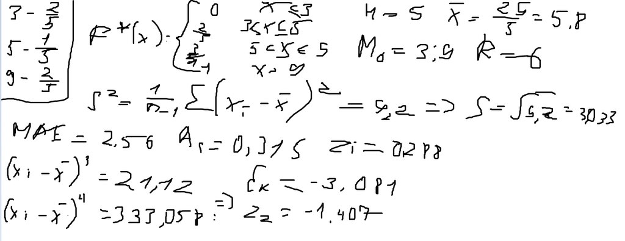

## Контрольні питання

### 1. Вибірковий метод — це основний інструмент математичної статистики. Його суть полягає в тому, що замість дослідження всіх об’єктів , ми досліджуємо лише їхню частину, а висновки поширюємо на всіх.Цей метод використовується для економії часу та ресурсів, а також у випадках, коли перевірити кожен об'єкт неможливо.

### 2. Основними точковими оцінками є вибіркове середнє, яке визначає центр розподілу даних, та дисперсія , що показує міру їхнього розсіювання.Вибіркове середнє обчислюється діленням суми всіх значень вибірки на їхню загальну кількість.Дисперсія та середнє квадратичне відхилення розраховуються на основі суми квадратів різниць між кожним значенням вибірки та її середнім арифметичним.

### 3. На точність статистичних оцінок безпосередньо впливають обсяг вибірки та мінливість самих даних у генеральній сукупності.Крім того, критично важливою є репрезентативність вибірки, яка забезпечується правильним і випадковим методом відбору об'єктів, щоб уникнути системних помилок.

### 4. Вибіркове середнє обчислюється шляхом додавання всіх значень вибірки та діленням отриманої суми на загальну кількість елементів, що характеризує центр розподілу даних.Вибіркова дисперсія визначається як сума квадратів відхилень кожного значення від середнього, поділена на обсяг вибірки мінус один.

### 5. Точні вибіркові розподілення — це теоретичні закони, що описують ймовірність появи різних значень статистик при відборі з нормальної сукупності.Вони слугують математичним еталоном, який дозволяє оцінити точність вибіркових даних та розрахувати можливу похибку репрезентативності.Саме на основі цих розподілень будуються довірчі інтервали та здійснюється перевірка статистичних гіпотез, що дає змогу робити обґрунтовані висновки про генеральну сукупність навіть за малими вибірками.

### 6. Головною властивістю інтервальної оцінки є надійність, яка визначає ймовірність того, що побудований інтервал містить істинне значення невідомого параметра генеральної сукупності.Другою властивістю є точність, яка визначається шириною цього інтервалу: чим він вужчий, тим інформативнішою є оцінка.Між ними існує компроміс: підвищення надійності неминуче призводить до розширення інтервалу, і покращити обидва показники одночасно можна лише шляхом збільшення обсягу вибірки.

### 7. Спочатку обчислюється точкова оцінка параметра, яка стає центром майбутнього інтервалу.Потім, виходячи з обраного рівня надійності та мінливості даних, розраховується гранична похибка, яка визначає ширину цього інтервалу.На завершення цю похибку віднімають від центру та додають до нього, формуючи нижню та верхню межі, в яких гарантовано знаходиться шуканий параметр.

### 8. Довірчий інтервал будується навколо знайденого вибіркового середнього шляхом додавання та віднімання від нього граничної похибки.Величина цієї похибки розраховується як добуток критичного коефіцієнта (Стьюдента для малих вибірок або Лапласа для великих) на стандартну похибку середнього.Отриманий інтервал гарантує, що з обраною ймовірністю істинне середнє значення генеральної сукупності знаходиться всередині цих меж.

### 9. Інтервальні оцінки дозволяють перевірити, чи відповідає реальний процес встановленим нормативам: якщо еталонне значення не потрапляє в інтервал, процес вважається порушеним.При порівнянні двох груп рішення приймається на основі перетину їхніх інтервалів: відсутність перетину свідчить про реальну, суттєву відмінність.Також нижня та верхня межі інтервалу використовуються для оцінки ризиків, дозволяючи будувати песимістичні та оптимістичні сценарії розвитку подій.

### 10. Для визначення обсягу вибірки використовують формульний метод, де кількість спостережень розраховується на основі допустимої похибки, бажаного рівня надійності та попередньої оцінки варіації даних (дисперсії).Для якісних показників використовують формулу з максимальною дисперсією, що гарантує репрезентативність навіть за повної невизначеності.Якщо генеральна сукупність мала, отриманий результат додатково коригують спеціальним коефіцієнтом, що дозволяє зменшити необхідну кількість досліджуваних об'єктів.

## Висновки

### На цьому практичному занятті ми познайомилися з базовими статистичним діями та поняттями та набули практичних навичок у розв’язанні типових задач з основ вибіркового методу, точкового та інтервального оцінювання числових характеристик випадкової величини.